# Predicting Yelp! Ratings

#### Wrangling the combined file

The code for this can be seen in appendix 3.

First, I combined the user and review dataframes into one called no_freq_data.

Next, using the tidytext and textdata packages, I took a list of all the words that have either a positive or negative connotation. I made each word a new column name. For each review, the number in that column refers to how many times that word was written in said review.

I save this dataset as freq_data to reflect the fact that this has columns for the frequency of words (as opposed to no_freq_data which does not). Now, it is worth noting that no_freq_data has 1,000,000 rows, whereas I was only able to get 10,000 rows for freq_data. This is due to RAM limitations. I will discuss the pros and cons of using each dataset later on.

```r
																											head(colnames(freq_data),30)
```

```
																											##  [1] "stars"                     "votes_received"
##  [3] "user_review_count"         "user_yelping_since"
##  [5] "user_friend_count"         "user_fans"
##  [7] "user_elite_status"         "user_votes_sent"
##  [9] "user_compliments_received" "abnormal"
## [11] "abound"                    "abounds"
## [13] "abrasive"                  "abrupt"
## [15] "abruptly"                  "absence"
## [17] "absurd"                    "absurdly"
## [19] "abundance"                 "abundant"
## [21] "abuse"                     "abused"
## [23] "abusive"                   "abysmal"
## [25] "abyss"                     "accessible"
## [27] "acclaimed"                 "accolade"
## [29] "accolades"                 "accomplish"
```

There are 2862 columns in this dataframe.

The column names of no_freq_data are:

```r
																											colnames(no_freq_data)
```

```
																											##  [1] "review_id"                 "user_id"
##  [3] "stars"                     "text"
##  [5] "year"                      "month"
##  [7] "day"                       "votes_received"
##  [9] "user_review_count"         "user_yelping_since"
## [11] "user_friend_count"         "user_fans"
## [13] "user_elite_status"         "user_votes_sent"
## [15] "user_compliments_received"
```

There are 15 columns in this dataframe.

## Data Exploration

#### What is the distribution of the number of stars?

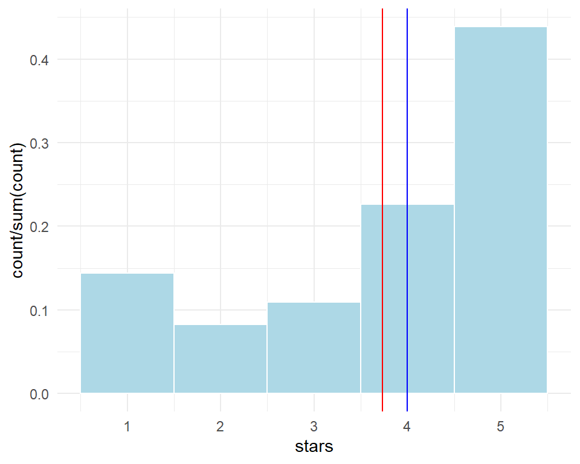

```r
																										ggplot(data = no_freq_data, aes(x=stars))+
  theme_minimal() +
  geom_histogram(aes(y=..count../sum(..count..)), bins=5, fill="lightblue", color = "white", ) +
  geom_vline(xintercept=mean(review_data_tidy$stars), colour="red") +
  geom_vline(xintercept=median(review_data_tidy$stars), colour="blue")
```

Here, using ggplot, I am plotting the frequency of the number of stars given. The red line shows the mean (at around 3.73), and the blue line shows the median (at 4).

We can see that almost half the reviews give the business 5 stars. Only about 1 in 5 reviews gave either a 2 or a 3 star rating. It seems like, the higher the number of stars, the more reviews. This excludes the 1 star rating which has a higher number of reviews than we’d expect. This does make sense intuitively, as someone will more likely leave a review if they have a particularly high or low opinion of the business.

Knowing the distribution of stars is not uniform is relevant to our data analysis; we want the model to predict the number of stars according to this distribution (not a uniform one).

#### Which words do we expect to indicate a good/bad review?

```r
																										#get list of words with positive connotations
positive_words <- get_sentiments("bing") %>%
  filter(sentiment == "positive")
```

```r
																										unnested_data <- select(no_freq_data,c("text", "review_id")) %>%
  unnest_tokens(word, text)
```

```r
																										#create table for positive words and their frequencies
good = unnested_data %>% select(word) %>%
  semi_join(positive_words) %>%
  count(word, sort = TRUE)
```

```r
																											#print the first 20 rows of the table
head(good,20)
```

```
																											##         word     n
## 1       good 52392
## 2      great 44448
## 3       like 35004
## 4       nice 18594
## 5       well 17557
## 6       best 17298
## 7       love 15929
## 8   friendly 14682
## 9  delicious 14145
## 10    pretty 12504
## 11   amazing 11911
## 12    better 11434
## 13     right 10670
## 14 recommend  9843
## 15     fresh  9069
## 16      work  8678
## 17   awesome  7355
## 18     worth  7219
## 19     super  7175
## 20     happy  7093
```

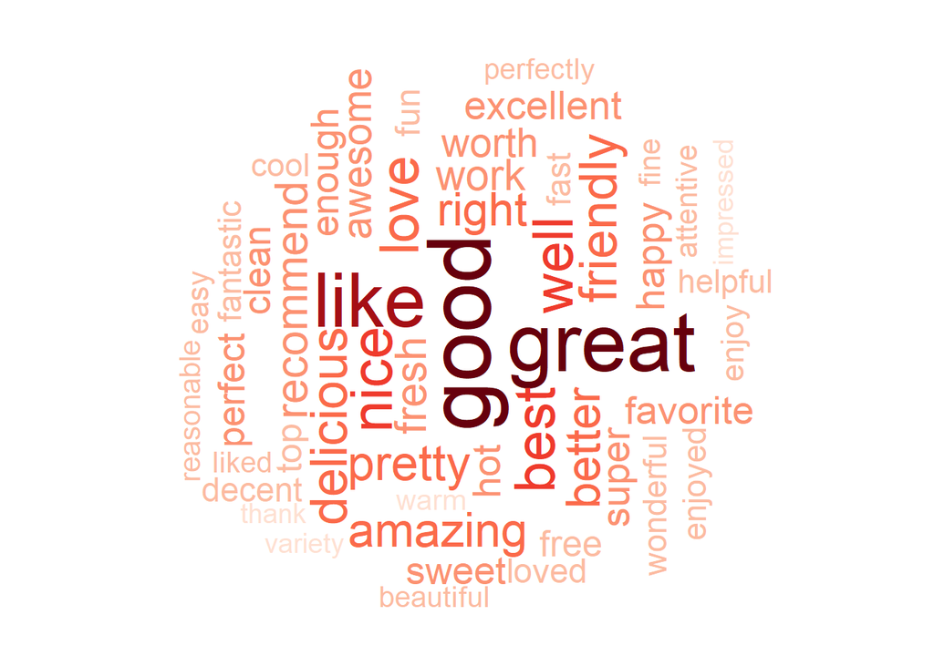

```r
																											#create a wordcloud to visualise frequencies
wordcloud(head(good,100)$word, sqrt(head(good,100)$n),max.words=50, random.order=FALSE, rot.per=0.5,colors=brewer.pal(9, "Reds"))
```

Here, I used the tidytext and the textdata packages, which allowed me a list of words that have positive connotations. I could cross reference these with the words used in reviews in order to create a frequency table, and a wordcloud (the latter from the wordcloud package).

```r
																											negative <- get_sentiments("bing") %>%
  filter(sentiment == "negative")

bad = unnested_data %>% select(word) %>%
  semi_join(negative) %>%
  count(word, sort = TRUE)
```

```r
																											head(bad,20)
```

```
																											##             word    n
## 1            bad 8192
## 2          fried 6142
## 3           hard 4185
## 4   disappointed 3919
## 5           cold 3501
## 6          wrong 3296
## 7          cheap 3027
## 8        problem 2889
## 9      expensive 2671
## 10          slow 2479
## 11          rude 2332
## 12         worst 2257
## 13      terrible 2132
## 14      horrible 1876
## 15         bland 1874
## 16         issue 1833
## 17          loud 1776
## 18 unfortunately 1772
## 19       crowded 1707
## 20        pricey 1650
```

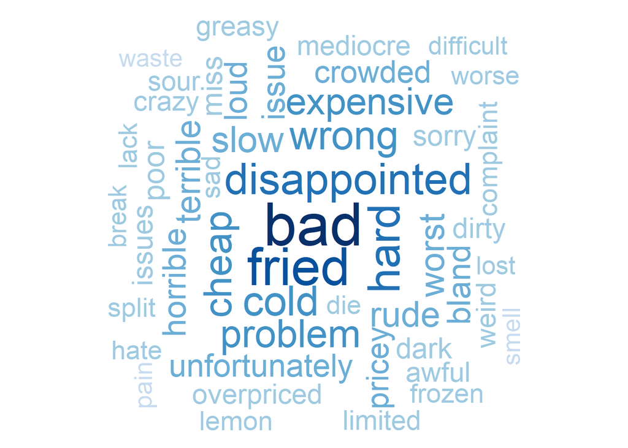

```r
																											wordcloud(head(bad,100)$word, sqrt(head(bad,100)$n), max.words=50, random.order=FALSE,rot.per=0.5,colors=brewer.pal(9, "Blues"))
```

This analysis tells us that using the tidytext classification of positive and negative words might be inaccurate, as it is not designed specifically for the data we are interested in. Some notable examples are:

- “waffle”, “yelp” and “cheap” are all negative words according to the dictionary that we are using. However, in context, these are all positive, or neutral words.
- “soup”, “lamb” and other food-related nouns are all labeled as positive, but in this context, they are most likely neutral as they don’t give any value judgement

It would be interesting to include this sort of sentiment analysis in our final model.

#### Do the number of stars depend on how many reviews a user has made?

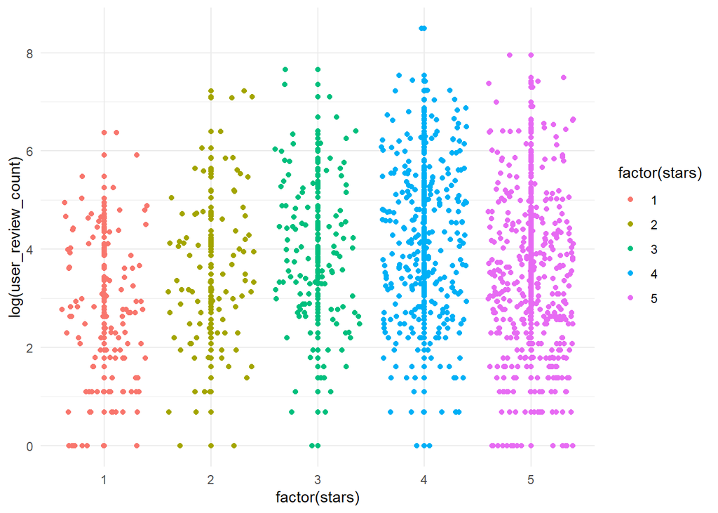

```r
																											ggplot(data = head(no_freq_data,1000), aes(y=log(user_review_count), x=factor(stars), colour=factor(stars)))+
  theme_minimal() +
  geom_point() +
  geom_jitter()
```

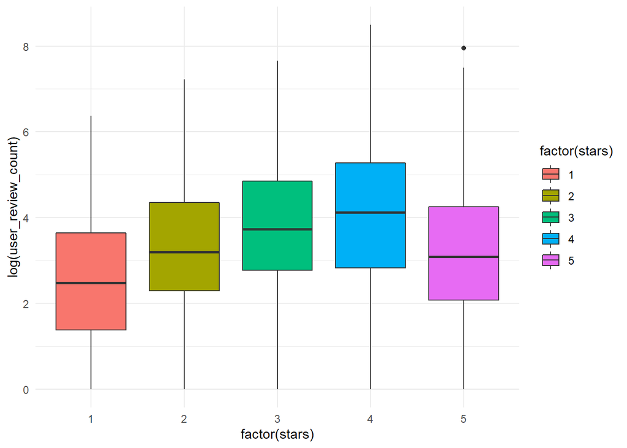

```r
																											ggplot(data = head(no_freq_data,1000), aes(y=log(user_review_count),x = factor(stars), fill=factor(stars))) +
  theme_minimal() +
  geom_boxplot()
```

I first used a scatter plot with jitter to plot the number of stars given against the log of the number of reviews left by a user. Since it’s quite hard to read, I also plotted a box and whisker plot.

We can see that there does seem to be some correlation between the review count and the number of stars. Whether this is significant or not is of course yet to be analyzed but the plots do indicate it is worth including in the data analysis later. The heights of the upper and lower quartiles and medians do seem change as the number of stars changes.

It appears that for any number of stars up to 4, the more stars given, the more reviews a user is likely to have given. For the five star case, however, the expected number of reviews is lower than the number expected for 2,3 or 4 stars.

It’s hard to say why this might be. Perhaps first time users are more likely to give an extreme rating, while long-time users are more nuanced.

It’s interesting to see that the shape of the box plots is very similar over the different star ratings.

It looks as if the user_review_count will be a useful explanatory variable in the model.

I first wanted to alter the no_freq_data dataframe to include the count of positive and negative words as explanatory variables:

```r
																											testpos <- unnested_data %>%
  semi_join(positive_words) %>%
  group_by(review_id) %>%
  summarize(positivewords=n())

testneg <- unnested_data %>%
  semi_join(negative) %>%
  group_by(review_id) %>%
  summarize(negativewords=n())

no_freq_data <- no_freq_data %>%
  left_join(testpos, by="review_id") %>%
  left_join(testneg, by="review_id")
```

Note that now we have two dataframes:

- freq_data has columns for the user data and for the frequencies of words. This has 10,000 rows
- no_freq_data has columns for the user dara and for the count of positive/negative words as classified by the tidytext package. This has 1,000,000 rows.

Weighing up the positives and negatives of both, we have:

*freq_data*

- Many more columns - takes longer to run
- More complicated model - Occam’s razor
- The variables appear to explain variation in the data
- Fewer datapoints available

*no_freq_data*

- Fewer columns
- Less complicated model
- Influenced by tidytext’s classification of positive/negative sentiment
- Many more datapoints available

I will use analysis to determine which is best, but first I want to do some more data exploration.

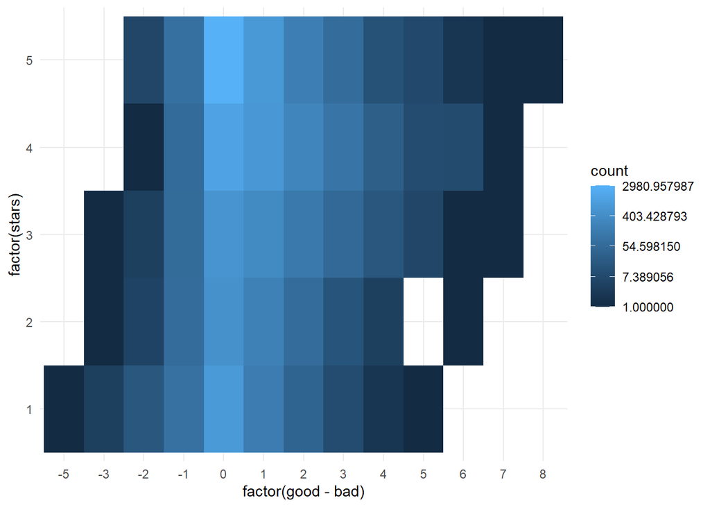

```r
																											freq_data %>% ggplot(aes(x=factor(good-bad),y=factor(stars)))+geom_bin2d()+theme_minimal()+
  scale_fill_gradient(trans = "log")
```

Here, I am using freq_data.

I find the frequency of the word “good” and subtract the frequency of the word “bad” for each review. I then plot this against the star rating.

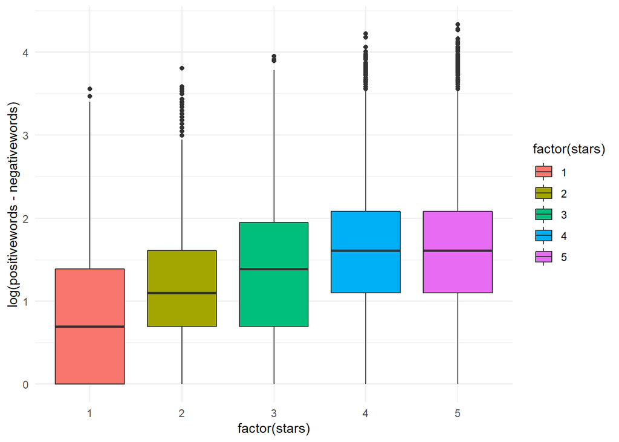

```r
																											ggplot(data=no_freq_data, aes(x=factor(stars), y=log(positivewords-negativewords), fill=factor(stars))) +geom_boxplot()+theme_minimal()
```

Here, I am using no_freq_data.

I plot the frequency of positive subtract the number of negative words against the star rating.

It appears that there is some correlation in both cases. It is hard to see from the data exploration which set of explanatory variables will work best for our purposes.

## Analytical Method

My plan is to initially fit a tree to both no_freq_data and freq_data in order to compare them both. Then, moving forward with the best dataset, I plan to use a random forest for my final model.

The reason for this choice is that ranger() is extremely efficient and will be able to cope with our large dataset. Since our data is categorical, and we don’t expect a linear relationship between our explanatory and response variable, this seems like a good fit. We don’t have to worry so much about overfitting since the errors are different for each tree and will hopefully average out across the forest.

Regression would be hard to apply to freq_data due to the sheer number of explanatory variables. Here, we have 2861 different columns in our dataframe. Working in high dimensional space like this would likely take a huge amount of time if we were to use regression. We certainly couldn’t apply something like backwards variable selection since the model with every variable would be giant.

A linear model might be able to be used for no_freq_data. I think, however, a random forest would be better suited to the data, as well as faster and work better on a low RAM computer. It is hard to tell whether a linear model or a forest will do a better job in terms of mean squared error.

Initially, I will use rpart() on freq_data:

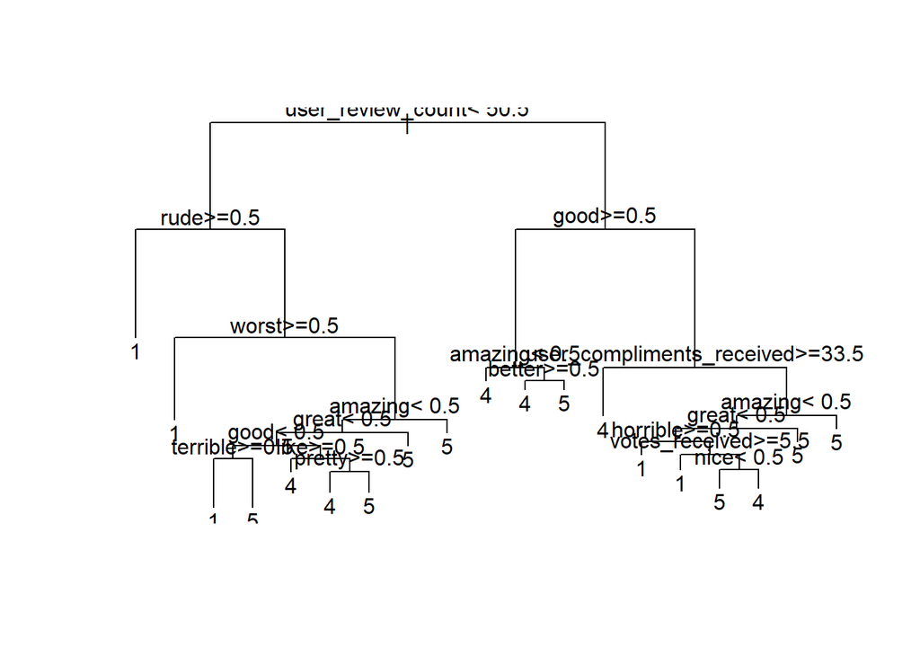

```r
																											freq_data = freq_data %>% select(-c("review_id", "text"))
tree = rpart(factor(stars)~., data=freq_data,
              control = rpart.control(cp = 0.0015))
plot(tree)
text(tree)
```

```r
																											tree
```

```
																											## n= 10000
##
## node), split, n, loss, yval, (yprob)
##       * denotes terminal node
##
##   1) root 10000 5806 5 (0.12 0.086 0.12 0.26 0.42)
##     2) user_review_count< 50.5 6212 3250 5 (0.16 0.084 0.088 0.2 0.48)
##       4) rude>=0.5 182   63 1 (0.65 0.14 0.1 0.055 0.044) *
##       5) rude< 0.5 6030 3076 5 (0.14 0.082 0.087 0.2 0.49)
##        10) worst>=0.5 114   25 1 (0.78 0.12 0.035 0.018 0.044) *
##        11) worst< 0.5 5916 2967 5 (0.13 0.081 0.088 0.2 0.5)
##          22) amazing< 0.5 5322 2832 5 (0.14 0.087 0.093 0.21 0.47)
##            44) great< 0.5 3703 2146 5 (0.18 0.1 0.1 0.19 0.42)
##              88) good< 0.5 2561 1380 5 (0.22 0.095 0.076 0.15 0.46)
##               176) terrible>=0.5 60   10 1 (0.83 0.083 0.067 0.017 0) *
##               177) terrible< 0.5 2501 1320 5 (0.2 0.096 0.076 0.15 0.47) *
##              89) good>=0.5 1142  766 5 (0.11 0.12 0.16 0.28 0.33)
##               178) like>=0.5 306  232 4 (0.15 0.18 0.2 0.24 0.23) *
##               179) like< 0.5 836  530 5 (0.089 0.097 0.15 0.3 0.37)
##                 358) pretty>=0.5 115   70 4 (0.052 0.11 0.23 0.39 0.21) *
##                 359) pretty< 0.5 721  439 5 (0.094 0.094 0.14 0.28 0.39) *
##            45) great>=0.5 1619  686 5 (0.043 0.052 0.072 0.26 0.58) *
##          23) amazing>=0.5 594  135 5 (0.015 0.029 0.044 0.14 0.77) *
##     3) user_review_count>=50.5 3788 2447 4 (0.056 0.089 0.18 0.35 0.33)
##       6) good>=0.5 1544  898 4 (0.032 0.083 0.21 0.42 0.26)
##        12) amazing< 0.5 1408  813 4 (0.035 0.087 0.22 0.42 0.24) *
##        13) amazing>=0.5 136   73 5 (0.0074 0.044 0.11 0.38 0.46)
##          26) better>=0.5 20    8 4 (0 0.1 0.15 0.6 0.15) *
##          27) better< 0.5 116   56 5 (0.0086 0.034 0.1 0.34 0.52) *
##       7) good< 0.5 2244 1407 5 (0.073 0.093 0.15 0.31 0.37)
##        14) user_compliments_received>=33.5 1068  690 4 (0.044 0.1 0.19 0.35 0.31) *
##        15) user_compliments_received< 33.5 1176  668 5 (0.099 0.083 0.12 0.27 0.43)
##          30) amazing< 0.5 1063  633 5 (0.11 0.089 0.12 0.27 0.4)
##            60) great< 0.5 764  484 5 (0.14 0.1 0.14 0.25 0.37)
##             120) horrible>=0.5 10    0 1 (1 0 0 0 0) *
##             121) horrible< 0.5 754  474 5 (0.13 0.1 0.14 0.25 0.37)
##               242) votes_received>=5.5 42   21 1 (0.5 0.12 0.048 0.19 0.14) *
##               243) votes_received< 5.5 712  438 5 (0.11 0.1 0.14 0.26 0.38)
##                 486) nice< 0.5 618  367 5 (0.13 0.099 0.14 0.23 0.41) *
##                 487) nice>=0.5 94   52 4 (0.011 0.14 0.16 0.45 0.24) *
##            61) great>=0.5 299  149 5 (0.017 0.054 0.09 0.34 0.5) *
##          31) amazing>=0.5 113   35 5 (0.0088 0.027 0.053 0.22 0.69) *
```

My intuition was correct in that user_review_count is a very strong indicator of star rating, as well as the frequency of the word “good”. Lots of the other variables that come up were all part of the word cloud we looked at earlier.

The above tree has a high complexity parameter so we can get an idea of the structure. However, I also wanted to apply a more complex tree:

```r
																											#models using a more complicated tree
complex_tree = rpart(factor(stars)~., data = head(freq_data,9000), control=rpart.control(cp=0.00001, xval=10))
```

```r
																											conf_matr = table(predict(complex_tree, tail(freq_data[,-1],1000)) %>% apply(1,function(x){which.max(x)}), tail(freq_data,1000)$stars)
conf_matr
```

```
																											##
##       1   2   3   4   5
##   1  49  14   7  12  13
##   2   6   4  15  15  14
##   3   8   8  12  20  11
##   4   7  27  39  83 109
##   5  38  25  61 133 270
```

```r
																											#how many did it get right??
sum(diag(conf_matr))/1000
```

```
																											## [1] 0.418
```

We have a correct prediction of 41.8% which is not bad, seeing as there are five categories to sort the data into.

Let’s see what happens if we apply the same model to no_freq_data – this is the same data but without the frequencies of words. I will only take the first 10,000 lines so that the comparison is fair.

```r
																											no_freq_data = no_freq_data %>% select(-c("review_id", "user_id", "text"))

nofreq_tree = rpart(factor(stars)~., data = head(no_freq_data,9000), control=rpart.control(cp=0.00001, xval=10))

conf_matr = table(predict(nofreq_tree, tail(no_freq_data[,-1],1000)) %>% apply(1,function(x){which.max(x)}), tail(no_freq_data,1000)$stars)
conf_matr
```

```
																											##
##       1   2   3   4   5
##   1  51  18  13  11  22
##   2  18   9  14  10  15
##   3   6  12   7  24  24
##   4  13  22  34 100 100
##   5  33  26  47 109 262
```

```r
																											#how many did it get right??
sum(diag(conf_matr))/1000
```

```
																											## [1] 0.429
```

Let’s continue with the no_freq_data then!

I will apply a random forest. I will need to test different values of mtry - this is the number of variables to split into at each node. The default value is $\lfloor\sqrt{P}\rfloor$ which is 3 - I will try some other values and see which works best.

```r
																											no_freq_data[is.na(no_freq_data)] <- 0
p = ncol(no_freq_data)-1
rows = nrow(no_freq_data)
mtry = c(1,2,3,4,5)
oob = c()

for (i in mtry){
nofreq_forest = ranger(factor(stars)~., data = head(no_freq_data,10000), mtry=i, verbose=FALSE, min.node.size = 1, num.trees=50, importance="permutation", classification = TRUE)
oob = c(oob, sum(diag(table(true=tail(no_freq_data$stars,10000), pred=predict(nofreq_forest, data=tail(no_freq_data,10000))$predictions)))/10000)
}

cbind(mtry, oob)
```

```
																											##      mtry    oob
## [1,]    1 0.4751
## [2,]    2 0.5032
## [3,]    3 0.5020
## [4,]    4 0.4941
## [5,]    5 0.4968
```

```r
																											mtry = mtry[which.max(oob)]
```

It seems like mtry=2 is the best option, so I’ll stick to that.

We have seen in class that we cannot overfit by using too many trees (num.trees) and so I will make this as large as I can run in a reasonable amount of time on my computer. Let’s try 100 trees.

```r
																											nofreq_forest = ranger(factor(stars)~., data = no_freq_data, mtry=mtry, verbose=FALSE, min.node.size = 1, num.trees=100, importance="permutation", classification = TRUE)
```

## Results

```r
																											nofreq_forest
```

```
																											## Ranger result
##
## Call:
##  ranger(factor(stars) ~ ., data = no_freq_data, mtry = mtry, verbose = FALSE,      min.node.size = 1, num.trees = 100, importance = "permutation",      classification = TRUE)
##
## Type:                             Classification
## Number of trees:                  100
## Sample size:                      1000000
## Number of independent variables:  13
## Mtry:                             2
## Target node size:                 1
## Variable importance mode:         permutation
## Splitrule:                        gini
## OOB prediction error:             45.27 %
```

We get a out of box prediction error of 45.27%. This is not bad, especially since we do not have many explanatory variables and the ones we do have (except the number of positive/negative words) don’t intuitively explain much of the variation in star rating. I’m surprised the model does this well, since I wouldn’t have thought that the explanatory variables we have would be able to explain the difference between (for example) a 3 and a 4 star review.

```r
																											sort(nofreq_forest$variable.importance)
```

```
																											##                       day                     month        user_yelping_since
##              0.0002668555              0.0005891077              0.0061766194
##         user_friend_count         user_elite_status                      year
##              0.0077282606              0.0109382693              0.0112577947
##            votes_received                 user_fans           user_votes_sent
##              0.0122352783              0.0202708087              0.0287908760
## user_compliments_received         user_review_count             positivewords
##              0.0300447657              0.0397788822              0.0468372827
##             negativewords
##              0.0785777854
```

It looks like the variable importance (under the permutation measure) for each of the explanatory variables is positive; they all give a decrease in the out of bag error compared to when that value is randomly shuffled.

Month and day have the lowest variable importance, which is totally unsurprising. What I do find interesting is that their importance is non-negative. I can’t think of why this might be the case. Perhaps there is some sort of seasonal effect occurring. Or perhaps the variable importance is so close to zero that the positive permutation score is just due to randomness.

The variables with the highest importance are unsurprisingly the count of positive and negative words. This is what we expected from the data exploration stage. These are the only variables that take into account the actual text of the review itself. The number of negative words is apparently more important than the number of positive words. Perhaps a user who rates a business very low is more likely to use more strong language than a user who rates a business very high.

The number of votes a review received was the only other explanatory variable from the review data. This had lower variable importance than I expected, but it was still positive.

In terms of user data, the number of reviews a user received, the number of fans, the number of votes sent and the number of compliments received all got a relatively high permutation variable importance. Again, we saw in the data exploration that the number of reviews was positively correlated with stars so this is unsurprising. The other user data: the year they have been yelping since, the friend count and the elite status were relatively less important.

If we look at the confusion matrix:

```r
																											nofreq_forest$confusion.matrix
```

```
																											##     predicted
## true      1      2      3      4      5
##    1 101915   3695   2580   4732  31247
##    2  29669   4016   5141  12516  31091
##    3  13164   3080   9405  34227  49278
##    4   9131   2562   9727  68154 136329
##    5  18814   2084   5065  48533 363845
```

We can see that there is a lot of confusion between 4 and 5. There is also a big confusion between 1 and 5 stars. I would guess that this is due to users with very little data about them and who didn’t leave very long reviews. Due to 1 and 5 being the most popular category, the model puts them there.

```r
																											pm1 = (sum(diag(nofreq_forest$confusion.matrix[-1,]) + diag(nofreq_forest$confusion.matrix[,-1])) + sum(diag(nofreq_forest$confusion.matrix)))/nrow(no_freq_data)
pm1
```

```
																											## [1] 0.817736
```

It’s interesting to note that 81.77% were guessed correctly to within one star! Again, I’m surprised by this accuracy.

Let’s try changing the response variable slightly. Let’s mutate the stars factor to be a 0 if a user left a one, two or three star review and a 1 if the review was four or five stars.

```r
																											no_freq_data_f = no_freq_data %>% mutate(stars_f = floor(stars/3.5)) %>%
  select(-"stars")

nofreq_forest_f = ranger(factor(stars_f)~., data = no_freq_data_f, mtry=mtry, verbose=FALSE, min.node.size = 1, num.trees=100, importance="permutation", classification = TRUE)

nofreq_forest_f
```

```
																											## Ranger result
##
## Call:
##  ranger(factor(stars_f) ~ ., data = no_freq_data_f, mtry = mtry,      verbose = FALSE, min.node.size = 1, num.trees = 100, importance = "permutation",      classification = TRUE)
##
## Type:                             Classification
## Number of trees:                  100
## Sample size:                      1000000
## Number of independent variables:  13
## Mtry:                             2
## Target node size:                 1
## Variable importance mode:         permutation
## Splitrule:                        gini
## OOB prediction error:             20.20 %
```

```r
																											sort(nofreq_forest_f$variable.importance)
```

```
																											##                       day                     month                      year
##              0.0002519867              0.0002529384              0.0040179356
##        user_yelping_since         user_friend_count         user_elite_status
##              0.0047230597              0.0090395884              0.0114048693
##            votes_received                 user_fans user_compliments_received
##              0.0121869375              0.0181252546              0.0257304565
##         user_review_count           user_votes_sent             positivewords
##              0.0273865167              0.0311796566              0.0632486147
##             negativewords
##              0.1135299080
```

```r
																											nofreq_forest_f$confusion.matrix
```

```
																											##     predicted
## true      0      1
##    0 196109 139647
##    1  62307 601937
```

The variable importance is very similar in this case, but the OOB prediction error is much lower at only 20.2%. It seems that, for a review that actually has a high star rating, the model is quite good at detecting such (it gets 90.62 % correct). However, for reviews that have a low rating, the model struggles more to place it (it only gets 58.41% correct).

## Conclusion

We have created a model that predicts the star rating (from 1 to 5) that a yelp review is given by a user, given the data yelp keeps about said user, as well as the count of words in the review with a positive/negative sentiment. The model predicts the correct star rating correctly 54.73% of the time, and is correct to within one star 81.77% of the time. We have created a similar model which predicts whether a review gets higher or lower than 3.5 stars with an accuracy of 79.8%.

## Discussion

#### Limitations

- The main limitation is my processing power. I do not have access to computers with a high amount of RAM or disk space. This puts a limit on the complexity of the models I can implement. More importantly, it restricts the size of the dataset I can use.
- The exploratory variables I have set up only record the number of times each word appears in the data. Although the package I am using accounts for variants of the same word (eg aches, ached, and ache all appear in the dataset), I cannot deal with phrases or combinations of words. For example, if one review says “very good” and another says “not good”, my data analysis would put them in the same category.
- A limitation could be words that are not included in the package. For example, swear words are not included, which could be an indicator that a reviewer feels very strongly about a business. There also might be slang words that are left off. In order to combat this, we’d have to use all the words used in the data, however, as processing power is already a limitation, this would be very hard for us.
- Misspellings are another limitation that, unless we went through the data manually, it is near impossible for us to deal with. We will have to make the assumption that the number of misspellings are small enough to not make a difference.

#### Strengths

- A strength is that we have a lot of data to work with. This means that the amount of data we have is not a limiting factor. If we were able to access a more powerful computer, our model would easily be flexible enough to be inputted more data.
- We have access to other data that yelp keeps on its users. As well as just using analysis on the words of the review itself, our model can be made much stronger by using these other attributes. For example, as we’ve seen in the data exploration, the number of reviews a user has made is quite a good indicator of the number of stars they will give.
- Another good thing is that we do not have to worry about missing data. Yelp keeps the same amount of information about all of it’s customers, so we do not need to worry about using missing data techniques in our model.

## Appendix

#### Appendix 1 - tidying review data

```r
																											#tidy review data
review_data_tidy <- review_data
  mutate("votes_received" = useful+funny+cool)%>%
  select(c("user_id", "votes_received", "stars", "text"))
```

#### Appendix 2 - tidying user data

```r
																											#tidy user data
user_data_tidy = user_data %>%
  mutate("elite_status" = if_else(elite=="", "no", "yes")) %>%
  mutate("votes_sent" = strtoi(useful)+strtoi(funny)+strtoi(cool)) %>%
  mutate("compliments_received" = strtoi(compliment_hot)+strtoi(compliment_more)+
           strtoi(compliment_profile)+strtoi(compliment_cute)+
           strtoi(compliment_list)+strtoi(compliment_note)+
           strtoi(compliment_plain)+strtoi(compliment_cool)+
           strtoi(compliment_funny)+strtoi(compliment_writer)+
           strtoi(compliment_photos)) %>%
  mutate("yelping_since" = substr(yelping_since,1,4))%>%
  mutate("friend_count"=if_else(friends=="None",0,str_count(friends, ",")+1))%>%
  select(c("user_id", "review_count", , "yelping_since", "friend_count", "fans",
           "elite_status", "votes_sent", "compliments_received")
         )%>%
  rename_all(~ paste0("user_", .x))%>% rename(user_id = user_user_id)
```

#### Appendix 3 - creating frequencies of words as exploratory variables

```r
																											no_freq_data = freq_data = freq_data_2 = review_data_tidy %>%
    left_join(user_data_tidy, by="user_id") %>%
    select(-c("user_id", "text"))
col_names = colnames(freq_data)

#remove words with special characters
wordlist = get_sentiments("bing")
wordlist = dplyr::filter(wordlist, !grepl('\\*', word))

#creates new columns for each word in wordlist giving frequency of that word in the review text
for (i in wordlist$word){
  assign(i,c())
  for(j in freq_data$text){
    review_string = tolower(gsub('[[:punct:] ]+',' ',j)) #removes punctuation and makes lowercase
    word_to_find = paste("", i, "") #makes sure the word is on its own (not part of a bigger word)
    count = str_count(review_string, word_to_find) #counts instances
    assign(i, c(get(i), count))
  }
  freq_data_2 = cbind(freq_data_2, get(i))
  col_names = c(col_names, toString(i))
  rm(list=i)
}

#removes the columns with all zeros
colnames(freq_data_2) = col_names

#removes columns we don't want
freq_data = freq_data_2[, colSums(freq_data_2!=0)>0] %>%
  select(-c("text", "user_id", "review_id", "year", "month","day"))
```